# Conectividade nas Escolas Cearenses

Este documento apresenta uma análise exploratória de dados e discussões acerca do acesso de estudantes de escolas públicas do Ceará à internet em suas respectivas instituições de ensino. Este trabalho é um requisito para aprovação na disciplina de Fundamentos de Estatística da Universidade de Fortaleza, no âmbito do curso de Inteligência Artificial.

**Autor:** Pedro Florencio de Almeida Neto | Cientista de Dados

**Objetivo Geral:**

- Fornecer subsídios descritivos para a análise da conectividade na educação no Estado do Ceará.

**Objetivos Específicos:**

- Descrever o acesso à internet nas instituições de ensino do Estado do Ceará.
- Organizar e apresentar indicadores descritivos, por meio de tabelas, gráficos e medidas estatísticas, que permitam a compreensão do cenário da conectividade educacional.

**Perguntas Norteadoras:**

1. Qual o percentual de escolas municipais, estaduais e federais no Estado do Ceará?
2. Qual o percentual de escolas rurais e urbanas no Estado?
3. Qual o panorama das escolas que tem laboratório de informática no Ceará?

### 1. Bibliotecas

### 2. Aquisição dos Dados

```r
df <- read_excel('data/processed-data/base_ceara_validada.xlsx')
df <- df[!is.na(df$escolar_co_municipio), ]
head(df)
```

| escolar_co_entidade | escolar_nu_ano_censo | escolar_no_entidade | escolar_tp_situacao_funcionamento | escolar_co_uf | escolar_co_municipio | escolar_co_distrito | escolar_tp_dependencia | escolar_tp_localizacao | escolar_qt_desktop_aluno | escolar_qt_comp_portatil_aluno | escolar_qt_tablet_aluno | escolar_in_laboratorio_informatica | escolar_in_internet | escolar_in_internet_alunos | escolar_in_internet_aprendizagem | escolar_tp_rede_local | escolar_energia | escolar_qtematriculas | escolar_qtematriculas_maior_turno | escolar_num_turmas | latitude | longitude | nm_regiao | nm_estado | nm_municipio | comparador_empresas | satelite_mec | recurso_recebido | porte_escola | … |
| --- | --- | --- | --- | --- | --- | --- | --- | --- | --- | --- | --- | --- | --- | --- | --- | --- | --- | --- | --- | --- | --- | --- | --- | --- | --- | --- | --- | --- | --- | --- |
| 23000465 | 2024 | JOAO LOURENCO PEREIRA ROCHA EEIEF | Em Atividade | 23 | 2300200 | 230020010 | Municipal | Rural | 0 | 0 | 0 | Nao | Sim | Nao | Sim | Wireless | PUBLICA | 270 | 157 | 12 | -2.826966 | -40.35846 | NORDESTE | CEARA | ACARAÚ | BRISANET SERVIÇOS, OI | TRUE | só AC | 201 a 500 | … |
| 23000660 | 2024 | MARIA NAZARE VIANA EEIEF | Em Atividade | 23 | 2300200 | 230020040 | Municipal | Rural | 0 | 0 | 0 | Nao | Sim | Nao | Sim | Wireless | PUBLICA | 222 | 118 | 13 | -3.021402 | -40.01231 | NORDESTE | CEARA | ACARAÚ | BRISANET SERVIÇOS, OI | TRUE | PIEC, Rural-4G e AC | 201 a 500 | … |
| 23000708 | 2024 | HIGINO DE SOUZA BRANDAO EEIEF | Em Atividade | 23 | 2300200 | 230020005 | Municipal | Urbana | 0 | 0 | 0 | Nao | Sim | Nao | Nao | Não informado | PUBLICA | 552 | 292 | 25 | -2.914451 | -40.12121 | NORDESTE | CEARA | ACARAÚ | BRISANET SERVIÇOS, OI | FALSE | PIEC e PBLE | 501 a 1000 | … |
| 23001119 | 2024 | RAIMUNDO ROSA DO NASCIMENTO EEIEF | Em Atividade | 23 | 2300200 | 230020040 | Municipal | Rural | 0 | 0 | 0 | Nao | Sim | Nao | Nao | Cabo e Wireless | PUBLICA | 105 | 62 | 6 | -3.077370 | -39.99957 | NORDESTE | CEARA | ACARAÚ | BRISANET SERVIÇOS, OI | FALSE | nenhum recurso | 51 a 200 | … |
| 23003014 | 2024 | MURILO ROCHA AGUIAR EEF DEP | Em Atividade | 23 | 2302602 | 230260205 | Municipal | Urbana | 0 | 0 | 0 | Nao | Sim | Sim | Sim | Cabo e Wireless | PUBLICA | 188 | 128 | 10 | -2.948096 | -40.83559 | NORDESTE | CEARA | CAMOCIM | NA | FALSE | só PIEC | 51 a 200 | … |
| 23003359 | 2024 | ANTONIO TEIXEIRA DE FRANCA EEF | Em Atividade | 23 | 2302602 | 230260225 | Municipal | Rural | 0 | 1 | 0 | Nao | Sim | Sim | Sim | Cabo e Wireless | PUBLICA | 88 | 63 | 5 | -2.890315 | -40.66179 | NORDESTE | CEARA | CAMOCIM | NA | FALSE | PIEC, Rural-4G e AC | 51 a 200 | … |

### 3. Pré-Processamento dos Dados

#### 3.1. Tratamento de dados ausentes

```r
# quantidade de codigos de municipio ausentes
sum(is.na(df$escolar_co_municipio))
```

```
[1] 0
```

### 4. Análise Exploratória dos Dados

#### 4.1. Qual o percentual de escolas municipais e estaduais no Estado do Ceará?

```r
# selecao das colunas necessarias
cols <- c("escolar_co_entidade", "escolar_no_entidade", "escolar_tp_dependencia")
df_dependencias <- df %>% select(all_of(cols))

# valores absolutos
df_freq <- as.data.frame(table(df_dependencias$escolar_tp_dependencia))
colnames(df_freq) <- c("TP_DEPENDENCIA","QUANTIDADE")

# percentual
df_freq$PERCENTUAL <- round(df_freq$QUANTIDADE/sum(df_freq$QUANTIDADE), 2)
```

```r
# visualizacao
df_freq %>%
  e_charts(TP_DEPENDENCIA) %>%
  e_pie(
    QUANTIDADE,
    radius = c("45%", "75%"),
    label = list(
      show = TRUE,
      position = "outside",
      formatter = "{d}%",
      fontSize = 12,
      color = "black"
    )
  ) %>%
  e_legend(right = "25%") %>%
  e_title(
    text = "Gráfico 01: Dependência Administrativa das Escolas Públicas do Ceará",
    textStyle = list(
      color = "black",
      fontSize = 14
    )) %>%
  e_theme("macarons")
```

[interactive chart not shown]

Observa-se uma predominância da quantidade de escolas municipais, isto é, de educação básica no estado do Ceará. Pode-se ressaltar que o número total de instituições não reflete necessariamente um alta taxa de escolarização, necessitando portanto de uma análise do número de matriculados em cada dependência administrativa no Estado.

#### 4.2. Qual o percentual de escolas rurais e urbanas no Estado do Ceará?

```r
# colunas necessarias
cols_necessary <- c('escolar_co_entidade',
                    'escolar_co_entidade',
                    'nm_municipio',
                    'escolar_tp_localizacao')

df_localizacao <- df %>% select(all_of(cols_necessary))

head(df_localizacao)
```

| escolar_co_entidade | nm_municipio | escolar_tp_localizacao |
| --- | --- | --- |
| 23000465 | ACARAÚ | Rural |
| 23000660 | ACARAÚ | Rural |
| 23000708 | ACARAÚ | Urbana |
| 23001119 | ACARAÚ | Rural |
| 23003014 | CAMOCIM | Urbana |
| 23003359 | CAMOCIM | Rural |

```r
# valores absolutos
df_freq_loc <- as.data.frame(table(df_localizacao$escolar_tp_localizacao))
colnames(df_freq_loc) <- c("TP_LOCALIZACAO","QUANTIDADE")

df_freq_loc
```

| TP_LOCALIZACAO | QUANTIDADE |
| --- | --- |
| Rural | 2509 |
| Urbana | 3462 |

```r
df_freq_loc %>%
  e_charts(TP_LOCALIZACAO) %>%
  e_bar(QUANTIDADE, name = "Área da instituição") %>%
  e_labels(show = TRUE) %>%
  e_title(text='Gráfico 02: Localização das Escolas Cearenses',
          textStyle = list(color = "black", fontSize = 14)) %>%
  e_theme('macarons')
```

[interactive chart not shown]

Há uma predominância de escolas em zona urbana, embora, a quantidade de instituições em zonas rurais apresenta-se com um valor relevante.

#### 4.3. Qual o panorama das escolas que tem laboratórios de informática no Ceará?

Adicionando dataframe com os limites do Estado do Ceará

```r
gdf_ceara <- st_read('data/processed-data/limites_ceara.geojson')
```

Selecionando as colunas necessárias

```r
cols_join <- c('escolar_no_entidade',
               'escolar_co_municipio',
               'nm_municipio',
               'escolar_tp_localizacao',
               'escolar_in_laboratorio_informatica',
               'escolar_in_internet',
               'escolar_tp_rede_local',
               'escolar_tipo_tecnologia',
               'escolar_in_internet_alunos',
               'escolar_in_internet_aprendizagem')

df_filtered <- df %>% select(all_of(cols_join))
```

```r
# substituindo coluna por variavel booleana
df_filtered <- df_filtered %>%
  mutate(escolar_in_laboratorio_informatica = ifelse(escolar_in_laboratorio_informatica == "Sim", 1, 0))
```

```r
# agrupando por municipio e somando a quantidade de laboratorios de informatica
df_filtered <- df_filtered %>%
  group_by(escolar_co_municipio) %>%
  summarise(
    quantidade_escolas_laboratorios = sum(escolar_in_laboratorio_informatica),
    quantidade_escolas = n())
```

Adicionando coluna com os valores relativos de escolas que contêm laboratórios de informática

```r
df_filtered <- mutate(df_filtered,
                      percentual_laboratorio = quantidade_escolas_laboratorios / quantidade_escolas)

View(df_filtered)
```

Adicionando a coluna *geometry* no dataframe *df_filtered*

```r
# padronizando tipo dos IDs dos municipios
df_filtered$escolar_co_municipio <- as.character(df_filtered$escolar_co_municipio)

df_join <- gdf_ceara %>%
  left_join(df_filtered, by = c("codigo_ibge"="escolar_co_municipio"))

dim(df_join)
```

```
[1] 184  10
```

Agrupando indicadores por município

```r
View(df_join)
```

A definição de quantidade de categorias seguiu-se a regra de *Freedman-Diaconis*[^1], em que:

$$w = 2*IQR*n^{-\frac{1}{3}}$$

$$k = \frac{max-min}{w}$$

Onde:

- **IQR**: amplitude interquartil
- **n**: número de observações
- **k**: quantidade de categorias (*bins*)

Para escolha dos valores que limitam cada categoria, adotou-se o método *Jenks-Caspall.*

```r
Q1 <- quantile(df_join$percentual_laboratorio, probs = 0.25)
Q2 <- quantile(df_join$percentual_laboratorio, probs = 0.50)
Q3 <- quantile(df_join$percentual_laboratorio, probs = 0.75)

IQR <- (Q3-Q1)

IQR
```

```
      75%
0.1794872
```

```r
n = nrow(df_join)
n
```

```
[1] 184
```

```r
w = 2*IQR*(n**(-1/3))
w
```

```
       75%
0.06311377
```

```r
min = min(df_join$percentual_laboratorio)
max = max(df_join$percentual_laboratorio)

k = (max - min)/w

k
```

```
     75%
15.01049
```

15 classes serão adotadas.

Aplicando o algoritmo de *Jenks-Caspall*, temos:

```r
categories <- getJenksBreaks(df_join$percentual_laboratorio, 15)
categories
```

```
 [1] 0.05263158 0.10000000 0.14285714 0.18750000 0.22916667 0.27272727 0.30434783 0.33333333 0.39130435 0.45555556
[11] 0.54166667 0.64285714 0.71457490 0.80357143 1.00000000
```

```r
# bins <- categories
bins <- 5 # Natural Breaks (Intervalos iguais)
pal <- colorRampPalette(brewer.pal(9, "YlOrRd"))(15)
pal_fun <- colorBin(
  palette = pal,
  domain = df_join$percentual_laboratorio,
  bins = "jenks",
  na.color = "transparent"
)
```

[output not shown]

Municípios com **menor percentual** de escolas com laboratórios

```r
df_order <- df_join %>% arrange(percentual_laboratorio)
head(select(as.data.frame(df_order),
                 municipio,
                 percentual_laboratorio,
                 quantidade_escolas_laboratorios,
                 quantidade_escolas),10)
```

|  | municipio | percentual_laboratorio | quantidade_escolas_laboratorios | quantidade_escolas |
| --- | --- | --- | --- | --- |
| 1 | Graça | 0.05263158 | 1 | 19 |
| 2 | Catarina | 0.05882353 | 1 | 17 |
| 3 | Aurora | 0.05882353 | 1 | 17 |
| 4 | Barroquinha | 0.06250000 | 1 | 16 |
| 5 | Capistrano | 0.06666667 | 1 | 15 |
| 6 | Quixelô | 0.06666667 | 1 | 15 |
| 7 | Meruoca | 0.07142857 | 1 | 14 |
| 8 | Ipueiras | 0.07272727 | 4 | 55 |
| 9 | Paraipaba | 0.07407407 | 2 | 27 |
| 10 | Croatá | 0.07500000 | 3 | 40 |

Avaliação da **disparidade** entre os municípios

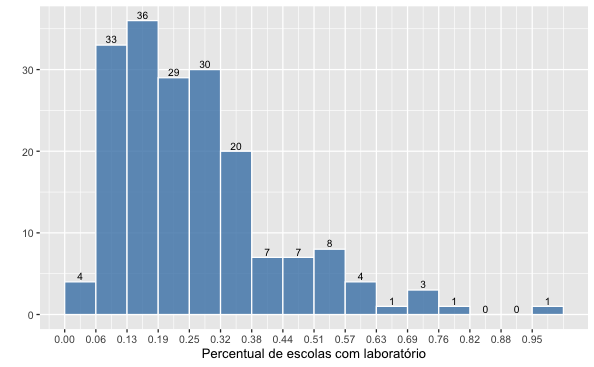

```r
ggplot(data=df_join) +
  geom_histogram(mapping = aes(x = percentual_laboratorio),
                 bins = 15,
                 binwidth = 0.063158,
                 fill = "steelblue",
                 color = "white",
                 alpha=0.8,
                 boundary=0) +
  scale_x_continuous(breaks = seq(0, 1, 0.063158),
                     labels = label_number(accuracy = 0.01)) +
  scale_y_continuous(breaks = seq(0, 40, 10)) +
  labs(x='Percentual de escolas com laboratório',y='') +
  geom_text(
    stat = "bin",
    aes(
      x = percentual_laboratorio,
      y = after_stat(count),
      label = after_stat(count)
    ),
    binwidth = 0.063158,
    boundary = 0,
    vjust = -0.3,
    size=3
  )
```

```r
summary(df_join$percentual_laboratorio)
```

```
   Min. 1st Qu.  Median    Mean 3rd Qu.    Max.
0.05263 0.15385 0.22822 0.26431 0.33333 1.00000
```

[^1]: https://geographicdata.science/book/intro.html